# Variável aleatória discreta

**Def.:** Seja $X$ uma variável aleatória (v.a.) discreta e $x_1, x_2, \ldots$ os possíveis valores de $X$. Denotamos por $P(X = x_i)$ a probabilidade do evento em que a v.a. $X$ assume o valor $x_i$. Assim a cada possível resultado $x_i$, associamos o número $P(x_i) = P(X = x_i)$ que será denominado **probabilidade de $x_i$**.

Desta forma, $P(x_i)$ deve satisfazer as seguintes condições:

- $P(x_i) \in [0, 1]$, $i = 1, 2, 3, \ldots$
- $\sum_{i=1}^{\infty} P(x_i) = 1$

**Def.:** A coleção de pares $(x_i, P(x_i))$ para $i = 1, 2, \ldots$ é chamada de **distribuição de probabilidade** da v.a. $X$.

### Distribuição Binomial

**A distribuição Binomial** é uma distribuição de probabilidade discreta que modela o número de sucessos em $n$ experimentos independentes, onde cada experimento tem dois possíveis resultados (sucesso ou fracasso).

A probabilidade de sucesso em um único experimento é denotada por $p$ e a probabilidade de fracasso é $1 - p$.

A fórmula da função de probabilidade para a distribuição binomial é dada por:

$P(X = k) = \binom{n}{k} p^k (1 - p)^{n - k}, \quad k = 0, 1, 2, \ldots, n.$

### Definições e Propriedades

- Notação: $X \sim Binomial(n, p)$
- Possíveis valores de $X$: $0, 1, 2, \ldots, n$
- Valor Esperado $E[X] = np$
- Variância $Var[X] = np(1 - p)$

### Gráfico da Distribuição

Abaixo apresentamos o gráfico da função de probabilidade da distribuição binomial com $n = 10$ e $p = 0.3$.

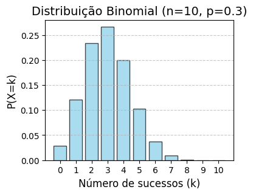